# Deconstructing Student Achievement: Coupling Dimensionality Reduction with Bayesian-Optimized Support Vector Machines Classifier

Steve Meadows

# Abstract

> This analysis investigates the drivers of secondary student academic success using data from the 2019 Parent and Family Involvement (PFI) Survey. To address the challenge of high-dimensional, mixed-type data with significant class imbalance, the study employs a comprehensive machine learning pipeline: dimensionality reduction via **PCAmix** followed by a cost-sensitive **Support Vector Machine (SVM)** classifier tuned with **Bayesian Optimization**. The findings highlight that while structural factors—such as household stability and socioeconomic status—establish a baseline for achievement, behavioral nuances play a critical role, distinguishing between proactive independent study habits and reactive parental intervention. Operationally, the model achieves a **90% recall rate** for identifying at-risk students. By prioritizing high sensitivity, the framework functions as a robust safety net, framing false positives not as prediction errors but as opportunities to expand support for students on the margins of success.

# Introduction

Understanding the factors that contribute to students’ academic success has become increasingly important as educators and researchers seek to disentangle the complex web of home and school influences. In this project, we analyze data from the **Parent and Family Involvement in Education (PFI) Survey**, a component of the [National Household Education Surveys Program (NHES)](https://nces.ed.gov/nhes/dataproducts.asp).

Administered by the **[U.S. Census Bureau](https://www.census.gov/programs-surveys/nhes.html)** on behalf of the National Center for Education Statistics (NCES), this nationally representative dataset provides a comprehensive view of the educational landscape, exploring relationships between family engagement, school choice, and student outcomes across the United States.

## Research Goal and Methodology

Our primary goal is to identify which latent profiles of family involvement—ranging from structural demographics to daily homework routines—are most strongly associated with markers of academic success.

Unlike traditional linear approaches, this analysis addresses the complexity of the PFI dataset—which contains a mix of numeric and categorical variables with significant class imbalance—through a robust machine learning framework. We utilize **PCAmix** (Principal Component Analysis for mixed data) to extract latent structures from the survey data, followed by a **Radial Basis Function (RBF) Support Vector Machine (SVM)**. To ensure optimal performance, the classifier is tuned using **Bayesian Optimization** and weighted to prioritize the detection of at-risk students.

By applying these statistical learning methods, we address the broader research question:

> **Which family and school-related factors best predict student academic success, and how can these insights guide the identification of at-risk student profiles?**

The final results are presented in this report, summarizing both the modeling process and our key findings. Ultimately, this analysis aims to demonstrate the efficacy of non-linear machine learning techniques in educational data mining, providing a rigorous framework for deconstructing the structural and behavioral drivers of achievement.

# Data Loading and Preprocessing

The analysis began by loading the 2019 Parent and Family Involvement (PFI) data from the curated Excel file and standardizing the grade variable (ALLGRADEX) so that Kindergarten categories were collapsed into a single value and grades 1–12 were mapped onto a consistent 1–12 scale. From this standardized variable, the analytic sample was restricted to secondary students only (grades 6–12). Next, the outcome variable SEGRADES was cleaned by treating special codes (-1 and 5) as missing, dropping cases with missing SEGRADES, and then recoding SEGRADES into a binary achievement indicator: students reporting mostly A’s/B’s (categories 1–2) were labeled “high” and those reporting mostly C’s or lower (categories 3–4) were labeled “low.” Finally, a set of identifying or analytically unnecessary variables (e.g., ZIP code, date of birth fields, interview identifiers, and raw grade variables) were removed to produce a streamlined dataset focused on secondary school students and a clean binary academic success outcome.

A predictive pipeline was constructed, incorporating dimensionality reduction via the `PCAmixdata` package followed by Support Vector Classification (SVC) utilizing the `e1071` library. To identify the optimal model configuration, hyperparameters—specifically `cost` (C) and `gamma`—were tuned through cross-validation and parallel Bayesian optimization. This optimization process, implemented via the `ParBayesianOptimization` package, selected the final model configuration by maximizing the Area Under the Precision-Recall Curve (PR-AUC) for the minority class.

# Dimensionality Reduction with PCAmix

Prior to fitting the PCAmix model, several preprocessing steps were undertaken to ensure compatibility with mixed-data factor extraction. In the PFI dataset, the value `-1` indicates a *valid skip* rather than a substantive numeric response. Because PCAmix replaces missing values in quantitative variables with the column mean, retaining `-1` would introduce artificial values into the covariance structure. Consequently, all `-1` entries in numeric variables were recoded as `NA`.

For qualitative variables, PCAmix operates on a disjunctive (indicator) matrix in which missing entries are replaced with zeros—an interpretation consistent with the absence of a selected response category in valid-skip cases. Given that the dataset includes both continuous measures (e.g., household size, work hours, parent age) and categorical survey responses, PCAmix is an appropriate framework, as it integrates PCA for quantitative variables with an MCA-like treatment for qualitative variables within a unified component solution. To support this structure, the small set of metrically continuous variables was explicitly identified, and all remaining predictors were converted to factors.

After generating stratified training and test splits on the binary success outcome, the outcome variable was removed, and `splitmix()` was applied to decompose the predictor set into quantitative (`X.quanti`) and qualitative (`X.quali`) blocks. This separation is required because PCAmix applies distinct mathematical transformations to numeric and categorical variables, producing interpretable mixed-data components suitable for downstream predictive modeling.

## Scree Plot for PCAmix Components

To evaluate the dimensional structure of the mixed data, a `PCAmix` model was fit using all available predictors in the training set, and the associated eigenvalues were extracted. Because `PCAmix` yields a component for each input variable, only the first 30 components were examined for interpretability. A scree plot was generated to visualize the rate at which variance declines across components and to identify potential elbows or diminishing returns in explained variance. This diagnostic informed the subsequent decision on how many components to retain for rotation and downstream modeling.

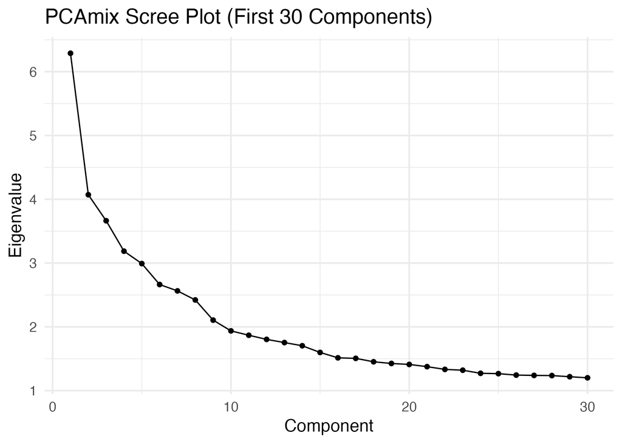

## Selection of 10 Principal Components

Component retention was guided by an inspection of the PCAmix scree plot and the corresponding eigenvalues. The initial components exhibit a steep decline in magnitude; specifically, Components 1–10 exceed an eigenvalue of approximately 1.9, capturing substantively meaningful variation. Beyond the tenth component, the curve flattens markedly, with eigenvalues ranging narrowly between 1.86 and 1.20 through Component 30. This gradual, nearly linear decrease signals the onset of the “long tail” region, where additional components provide limited incremental explanatory power.

While traditional heuristics such as Kaiser’s criterion (eigenvalues > 1) would suggest retaining a significantly larger number of components, such rules are known to result in over-retention when applied to large, mixed-data sets containing categorical indicators. Instead, priority was given to components that (a) lie above the discernible elbow in the scree plot, (b) exhibit noticeably larger eigenvalue magnitudes, and (c) support interpretable rotated factors. Under these criteria, a 10-component solution was selected as representing an optimal balance between parsimony and fidelity, preserving major structural dimensions while mitigating the inclusion of weak, noise-driven components. Consequently, this 10-component solution was utilized for rotation, interpretation, and downstream predictive modeling.

## Factor Analysis

To improve the interpretability of the ten retained principal components, a **Varimax rotation** was applied to the initial PCAmix solution using the `PCArot()` function. While the unrotated components maximize variance sequentially, they often produce “complex structure” where variables load moderately across multiple dimensions, making substantive interpretation difficult. The Varimax rotation orthogonalizes the components to maximize the variance of the squared loadings within each factor, pushing variable loadings toward either zero or one. This process yields a “simple structure” in which each variable associates primarily with a single latent factor, clarifying the underlying thematic constructs.

Following rotation, the squared loadings (`sqload`) were extracted and transformed by taking the square root to obtain loading magnitudes comparable to standard correlation coefficients. To facilitate a clear interpretation of the latent constructs, a **dominant loading approach** was employed. For each variable, only the single strongest factor loading was retained, provided it exceeded a minimum threshold of 0.30; all secondary cross-loadings were suppressed. This filtering process assigned each variable to its primary dimension, resulting in a clean, sparse factor matrix (see table below). This table serves as the basis for the thematic definitions of the ten latent constructs used in the subsequent predictive modeling.

### Rotated Factor Loadings

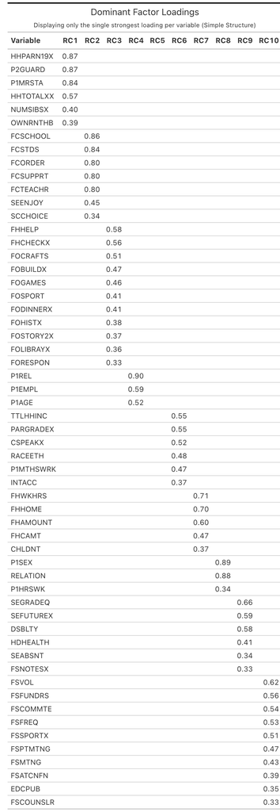

Interpretation of the rotated components yielded ten distinct latent factors that characterize the multidimensional nature of family involvement and student success. These constructs span structural domains—such as household stability, socioeconomic status, and parental demographics—as well as behavioral and perceptual domains, including active school participation, home-based learning routines, and school climate. The specific definitions, thematic interpretations, and dominant variables for each factor are detailed in the table below.

### Factor Definitions and Interpretations

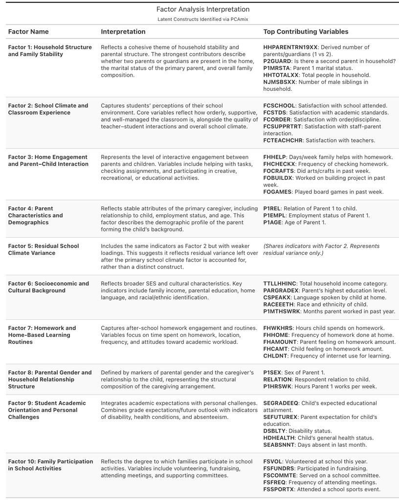

### Factor Profile Dumbbell Plot

To move beyond the analysis of individual survey items and understand the broader structural differences between student performance groups, the mean factor scores for high-success and low-success students were calculated across the ten latent constructs. Because factor scores are standardized (centered at 0 with a standard deviation of 1), they allow for a direct comparison of the magnitude of separation across distinct thematic domains.

A “dumbbell” or connected dot plot was employed to visualize these profiles. In this chart, the horizontal distance between the two points (the “dumbbell handle”) represents the discriminatory power of that specific factor. A wider gap indicates that the factor strongly distinguishes between high- and low-performing students, while a narrow gap suggests the factor is relatively uniform across the population regardless of academic outcome.

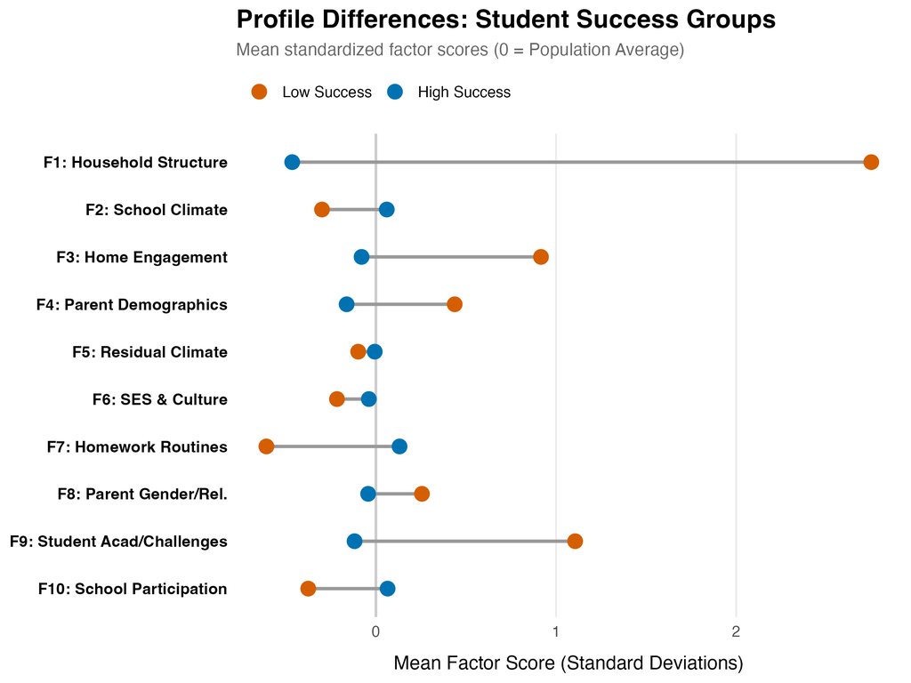

### Deep Dive: Deconstructing the Drivers of Success

Analysis of the standardized factor profiles revealed that the divergence between high- and low-success students is not uniform across all dimensions. Rather, the separation is driven by specific structural, behavioral, and demographic wedges. By ranking the factors based on the absolute difference in mean scores between groups, five distinct drivers emerge as the primary discriminators:

- Factor 1 (Household Structure): Exhibiting the largest magnitude of separation, this factor highlights that family composition is the single most defining structural difference in the dataset.
- Factor 9 (Academic Challenges): The second-largest gap appears here, confirming that non-academic barriers (such as health and absenteeism) effectively segregate the low-performing group.
- Factor 3 (Home Engagement): This factor displays the “reactive paradox,” where higher levels of direct parental help correlate with lower student success, suggesting intervention rather than enrichment.
- Factor 7 (Homework Routines): In contrast to Factor 3, this factor favors the high-success group, emphasizing the value of independent study habits and established routines.
- Factor 4 (Parent Demographics): Representing stability in age and employment, this factor underscores the role of parental resources and life stage.

While factor scores provide a high-level summary, they are abstract composites. To operationalize these findings, it is necessary to examine the constituent variables with the strongest loadings. The following section provides a granular analysis of the specific survey items driving these dominant factors, comparing the response distributions of high- and low-success students.

#### 1. Household Structure and Stability (Factor 1)

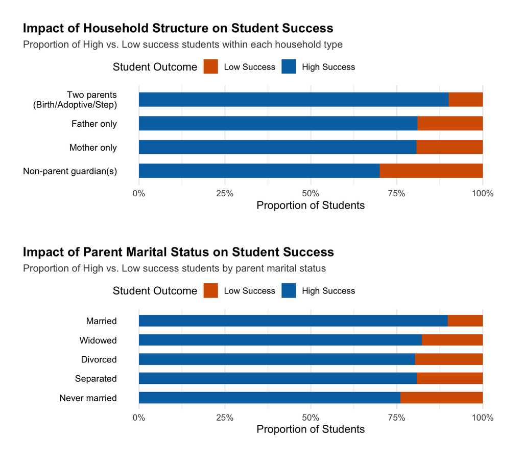

The most significant structural differentiator is the composition of the household. The data indicates that students in the high-success group are overwhelmingly concentrated in two-parent households (birth, adoptive, or step). Conversely, the low-success group shows a marked increase in single-parent or non-parent guardian arrangements. This aligns with the “Resource Dilution” theory, where the presence of two guardians increases the availability of time and financial resources per child.

Closely linked to household structure is the marital status of the primary parent. Stability appears to be the key driver here, with married parents showing the highest proportion of high-achieving students, while divorced or separated households show a proportionate increase in low-success outcomes.

#### 2. Aspirational Capital and Expectations (Factor 9)

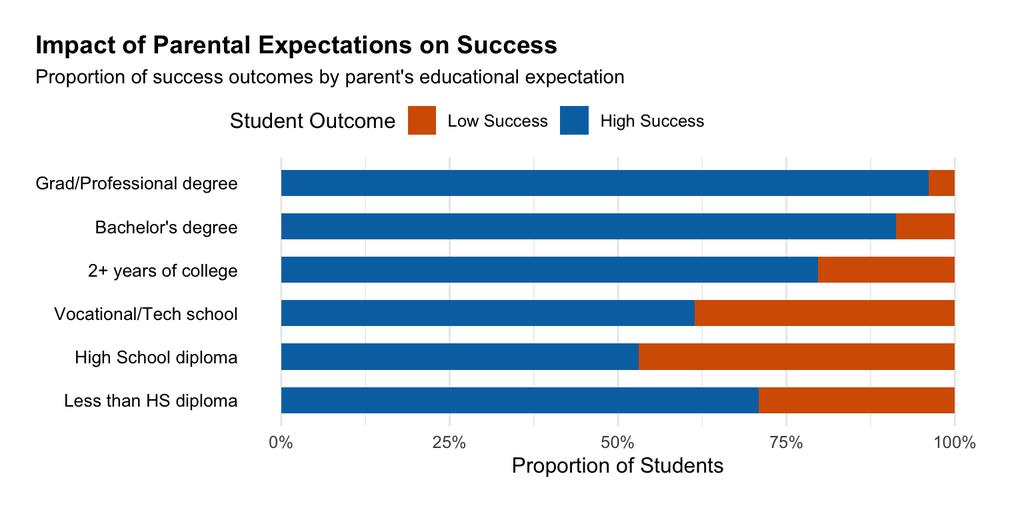

#### 3. Student Effort vs. Parental Monitoring (Factors 3 & 7)

The distinction between active student effort and parental monitoring is crystallized by the distribution of Weekly Homework Hours (FHWKHRS). While Factor 3 showed that parental checking is often reactive, Factor 7 confirms that student effort is a proactive driver of success.

The density plot below reveals a distinct “rightward shift” for the high-success group (blue). While the low-success group (orange) is narrowly concentrated at the lower end of the time scale (peaking sharply between 0–5 hours), the high-success distribution is flatter and extends significantly further into the higher hour ranges. This heavier tail indicates that sustained, independent study time is a robust predictor of academic achievement, distinguishing it from the remedial help often associated with lower outcomes.

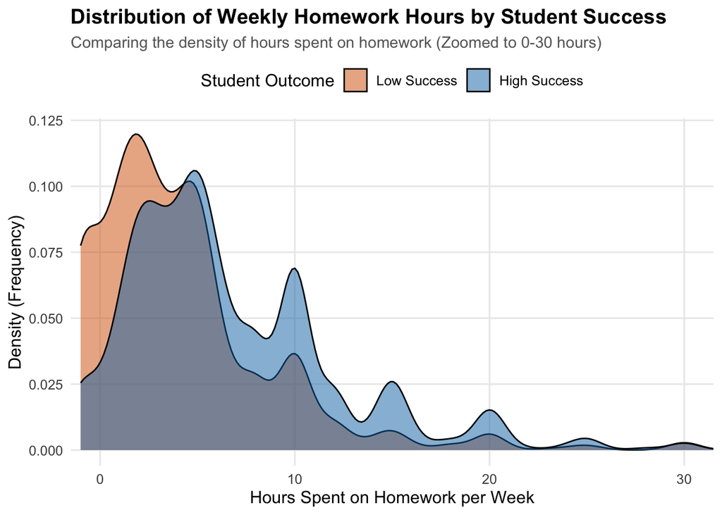

When examining Homework Frequency (a driver of Factor 7), we observe a clear positive correlation: students who engage in homework 5 or more days a week are significantly more likely to be in the high-success group. This reflects the consistency of the student’s own academic habit.

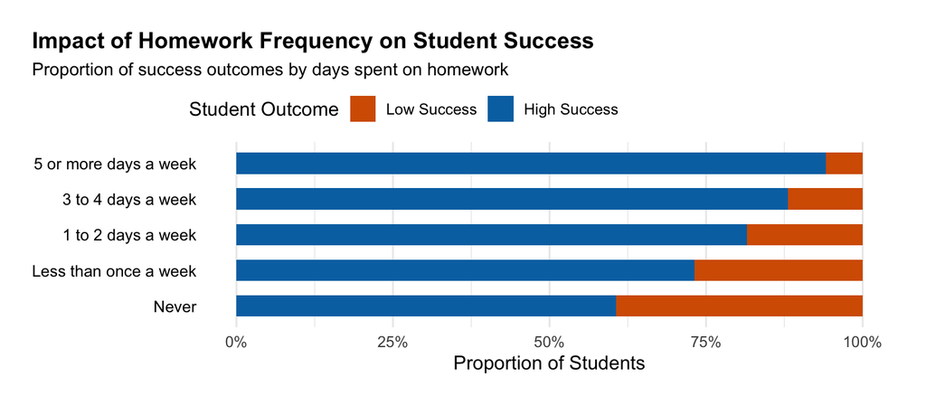

However, when examining Help Frequency (a driver of Factor 3), the relationship inverts. The cohort receiving the most frequent help (“3 or more days a week”) exhibits the highest probability of low success. This identifies intensive parental assistance as a lagging indicator—a response to existing academic deficits rather than a proactive driver of achievement.

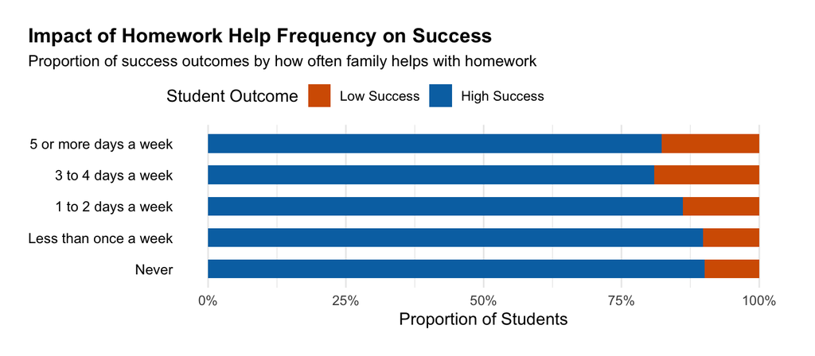

This “reactive” dynamic is further illustrated by parental perceptions of workload. Parents who feel the homework amount is “Too much” or “Too little” are more likely to have low-performing students, whereas the “About right” category—indicating alignment between school expectations and home capacity—correlates with the highest success rates.

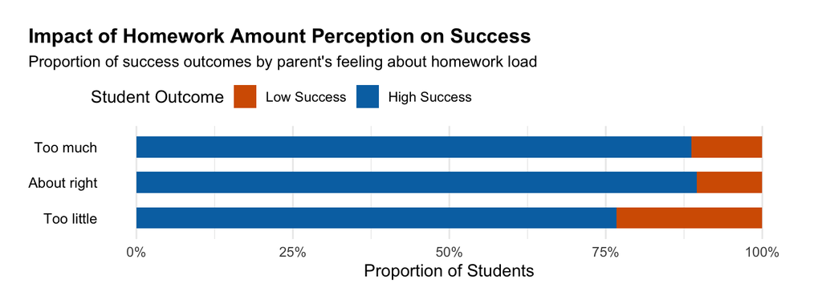

#### 4. Socioeconomic Context (Factors 4 & 6)

While Factors 4 and 6 represent demographic contexts, they provide the necessary backdrop for the structural and behavioral findings. As expected, Household Income shows a distinct gradient, where the likelihood of high success rises consistently with economic resources.

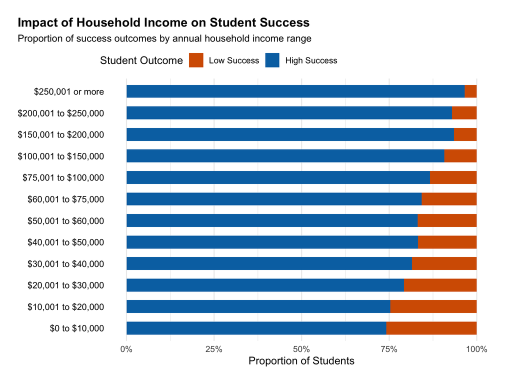

Similarly, Parental Education serves as a strong predictor, with a notable jump in student success rates for parents holding at least a Bachelor’s degree. This likely reflects not only economic stability but also a familiarity with the educational system that empowers parents to advocate effectively for their children.

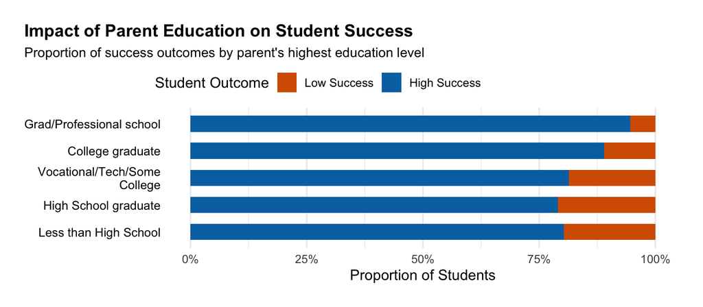

Finally, the analysis of Race and Ethnicity—a key component of Factor 6—reveals persistent disparities in academic outcomes across demographic groups. Consistent with broader educational trends, Asian or Pacific Islander and White students exhibit the highest proportions of academic success within this sample. In contrast, Black and Hispanic students are disproportionately represented in the low-success category. This stratification underscores the extent to which structural and systemic factors, captured within the broader socioeconomic dimension, continue to influence educational achievement.

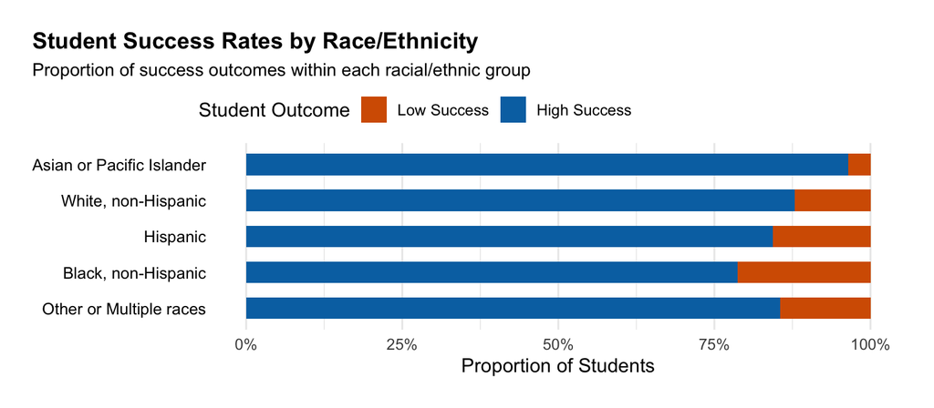

> Summary of Drivers

Collectively, this granular analysis underscores that student success is not driven by a single variable, but rather by an intricate interplay of structural advantages and behavioral patterns.

Three critical themes emerge from these findings:

**The Primacy of Structure:** Household stability (Factor 1) and socioeconomic resources (Factors 4 & 6) act as foundational multipliers. Students in two-parent, higher-income, and higher-education households possess a significant baseline advantage, confirming that academic outcomes are deeply rooted in the broader family context.

**The Quality of Engagement:** The data challenges the simplistic assumption that “more involvement is better.” The divergence between Factor 7 (Routines) and Factor 3 (Direct Help) demonstrates that fostering independent habits is a marker of success, while intensive direct assistance is often a lagging indicator of academic struggle.

**Systemic Stratification:** The persistent gaps observed across racial and health-related dimensions (Factor 9) highlight that non-academic barriers remain potent inhibitors of achievement.

These complex, non-monotonic relationships—particularly the “reactive help” paradox—validate the earlier decision to employ a non-linear SVM. A linear model would likely struggle to interpret why high parental involvement predicts lower success in some contexts (homework help) but higher success in others (routines). By capturing these distinct profiles, the model is better positioned to identify at-risk students who may be receiving help but lack the structural or habitual foundations for independent success.

## High-Dimensional Visualization via t-SNE

To investigate the separability of the student success classes beyond linear projections, t-Distributed Stochastic Neighbor Embedding (t-SNE) was applied to the ten retained principal components. Unlike PCA, which focuses on maximizing variance using linear combinations, t-SNE is a non-linear technique designed to preserve local neighborhoods, making it particularly effective for revealing clusters and sub-structures in high-dimensional data.

The algorithm was executed with a perplexity of 80 to balance the preservation of local and global structures. Given the substantial class imbalance, visualizing the full dataset would result in the minority class being visually overwhelmed by the majority. To address this, a balanced subset was constructed for the visualization, retaining all *low-success* cases and a random 10% sample of *high-success* cases.

[interactive chart not shown]

**Interpretation of Findings**

The resulting 3D embedding (visualized below) reveals a significant multi-modal structure characterized by several distinct sub-clusters rather than a simple, contiguous binary separation between high- and low-success groups. This observation implies three critical insights regarding the nature of the data and the necessary modeling strategy:

1. Heterogeneity and “Multiple Paths” to Success The presence of distinct “islands” containing high-success students suggests that the population is heterogeneous. “Student Success” is not defined by a monotonic increase in a single dimension (e.g., “more involvement is always better”). Instead, the data implies the existence of distinct parental profiles—unique combinations of socioeconomic resources, engagement levels, and household structures—that can independently lead to high academic achievement. For example, one cluster may represent families with high socioeconomic resources but lower direct school engagement, while another may represent lower-resource families with intense active volunteering. Both profiles achieve high success, yet they occupy completely different regions of the feature space.
2. Context-Dependent “Regimes” The visualization supports the theory that success is context-dependent. The relationship between specific factors (such as volunteering or homework help) and academic outcomes likely varies across these clusters. This suggests the existence of different “regimes” within the population, where the “rules” for achieving success change depending on the family’s specific demographic and structural profile.
3. Justification for the Radial Basis Function (RBF) Kernel Methodologically, the scattered distribution of these clusters provides empirical justification for the choice of SVM kernel. A linear classifier draws a single flat hyperplane through the feature space; such a model would fail to separate these non-contiguous, multi-modal “islands” of success effectively. To capture this complexity, a non-linear Radial Basis Function (RBF) kernel is required. The RBF kernel allows the model to construct localized decision boundaries (“circles”) around specific clusters, enabling it to distinguish between high- and low-success students across the various distinct profiles present in the data.

# Fitting SVM model

To tune the radial-basis SVM classifier, two key hyperparameters were optimized: **cost** ($C$) and **gamma** ($\gamma$). The model utilizes the **kernel trick** to map input vectors into a high-dimensional feature space where non-linear relationships become linearly separable. Specifically, the Radial Basis Function (RBF) kernel is defined as:

$$K(\mathbf{x}_i, \mathbf{x}_j) = \exp(-\gamma \|\mathbf{x}_i -
\mathbf{x}_j\|^2)$$

The **gamma** ($\gamma$) parameter controls the width of this Gaussian function. Mathematically, it acts as the inverse of the radius of influence of samples selected by the model as support vectors. Low gamma values generate smoother, more global decision boundaries (large variance), whereas high gamma values produce highly localized boundaries (small variance) that risk capturing noise in the training set.

The **cost** ($C$) parameter regulates the trade-off between maximizing the margin width and minimizing the classification error on the training data. This is formalized in the soft-margin SVM objective function, which seeks to minimize:

$$\min_{\mathbf{w}, b, \xi} \left( \frac{1}{2}\|\mathbf{w}\|^2 + C
\sum_{i=1}^{n} \xi_i \right)$$

subject to the constraints $y_i(\mathbf{w}^T \phi(\mathbf{x}_i) + b) \geq 1 - \xi_i$, where $\xi_i$ represents the slack variables that allow for misclassification. Smaller values of $C$ allow for larger slack (a softer, more flexible margin), while larger values enforce stricter separation (heavier penalty on $\xi_i$) that can lead to overfitting.

Given the strong imbalance in the dataset—with *low-success* students appearing far less frequently than *high-success* students—**class weights** ($W_j$) were incorporated directly into the penalty term of the objective function. Weights proportional to the inverse class frequencies were computed as follows:

- **low**: 6.562753
- **high**: 1.0000

This weighting scheme modifies the optimization problem to minimize:

$$\frac{1}{2}\|\mathbf{w}\|^2 + C \sum_{i=1}^{n} W_{y_i} \xi_i$$

By assigning $W_{low} \approx 6.6$, the effective penalty for misclassifying a minority *low* case becomes nearly seven times higher than that of a *high* case. This prevents the classifier from defaulting to the majority class and ensures that the decision boundary is shaped to improve detection of the students most relevant to the prediction objective.

To systematically identify the optimal balance between these regularization parameters and the assigned class weights, hyperparameter performance was evaluated using five-fold stratified cross-validation. This approach preserved the proportion of low and high cases in each fold; for each ($C$, $\gamma$) pair proposed, the SVM was trained on four folds and evaluated on the remaining fold. Performance was quantified using the Precision–Recall Area Under the Curve (PR-AUC) computed for the low class. PR-AUC was selected over ROC-AUC due to the imbalanced outcome, as it provides a more direct measure of the classifier’s ability to identify and rank the minority group—the primary target for early detection—without being inflated by the large number of true negatives.

Bayesian optimization (utilizing an Expected Improvement acquisition function) was employed to efficiently navigate this hyperparameter space, balancing the exploration of uncertain regions with the exploitation of promising ones. The process converged on a well-regularized configuration: cost = 0.10 and gamma = 0.01, yielding a cross-validated PR-AUC of 0.5811. Training a final model on the full training set with these tuned parameters produced a test-set PR-AUC of 0.6340, indicating improved generalization and effective discrimination of low-success students despite substantial class imbalance.

## Relationship Between Hyperparameters and Model Performance

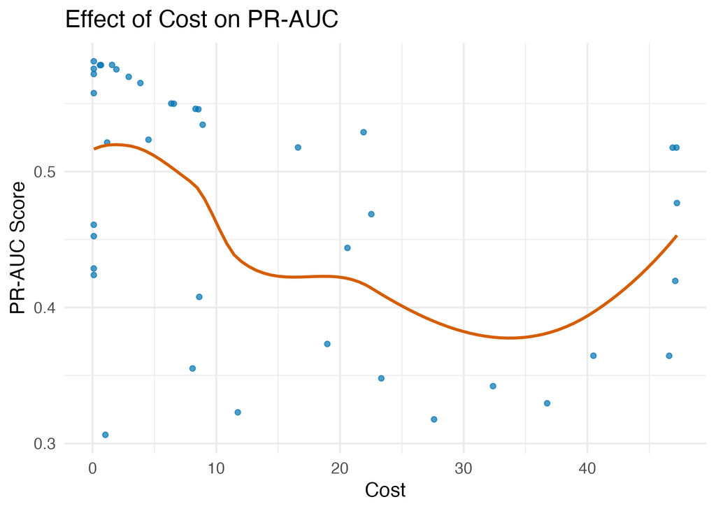

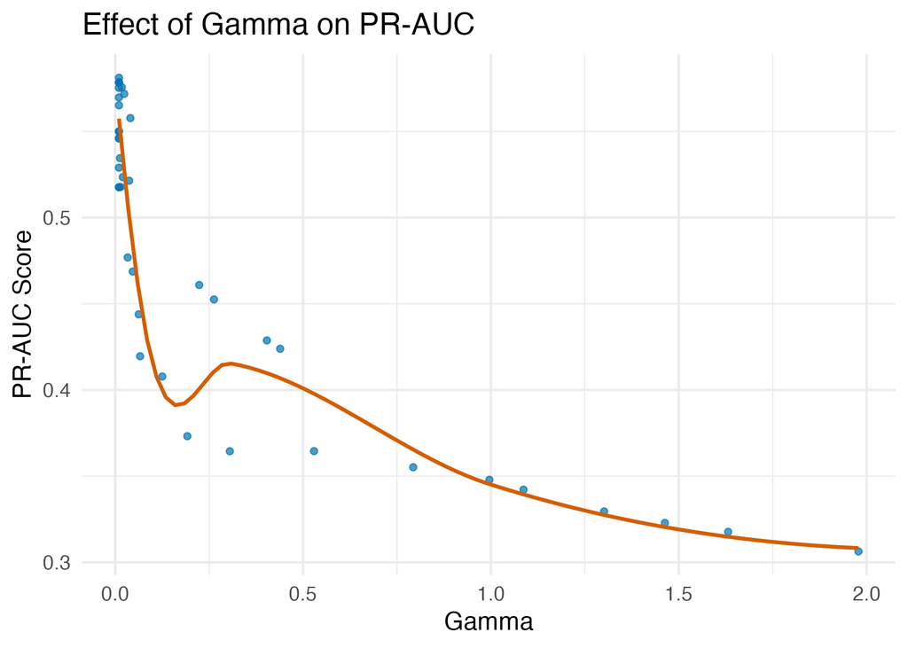

The scatter plots of PR-AUC against **cost** and **gamma** reveal a clear structural pattern in how the SVM responds to regularization. Models achieve their strongest performance when **cost is small** and **gamma is extremely small**, indicating that the classifier benefits from a **soft margin** and a **very smooth, broad RBF kernel**. As either hyperparameter increases—especially when gamma becomes moderate or large—the PR-AUC drops sharply. This pattern shows that highly flexible or highly localized decision boundaries (high gamma or high cost) tend to overfit the majority class and degrade ranking performance for the minority *low-success* group. Conversely, the highest PR-AUC values cluster in the region where the boundary is simple and heavily regularized, consistent with the final optimal configuration (cost = 0.10, gamma = 0.01).

## SVM Confusion Matrix on Test Data

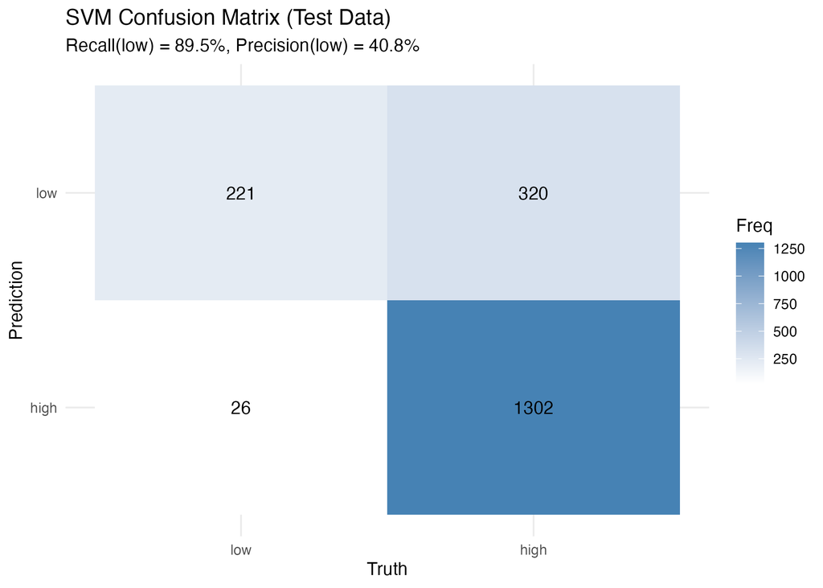

The confusion matrix displays predicted classes on the rows and true classes on the columns. Thus, each cell reflects how often the model assigned a given label relative to the actual outcome.

- **Predicted low / True low (TP)**: 221
- **Predicted low / True high (FP)**: 320
- **Predicted high / True low (FN)**: 26
- **Predicted high / True high (TN)**: 1302

Interpreting *low* as the at-risk (positive) class:

- **Recall (sensitivity)** = 221 / (221 + 26) ≈ **89.5%**
  - The model correctly identifies most low-success students and rarely misses them.
- **Precision** = 221 / (221 + 320) ≈ **40.8%**
  - Of all students predicted to be low-success, only about 41% actually are; the remainder are false alarms.
- **Overall accuracy** ≈ (221 + 1302) / (221 + 320 + 26 + 1302) ≈ **81.5%**

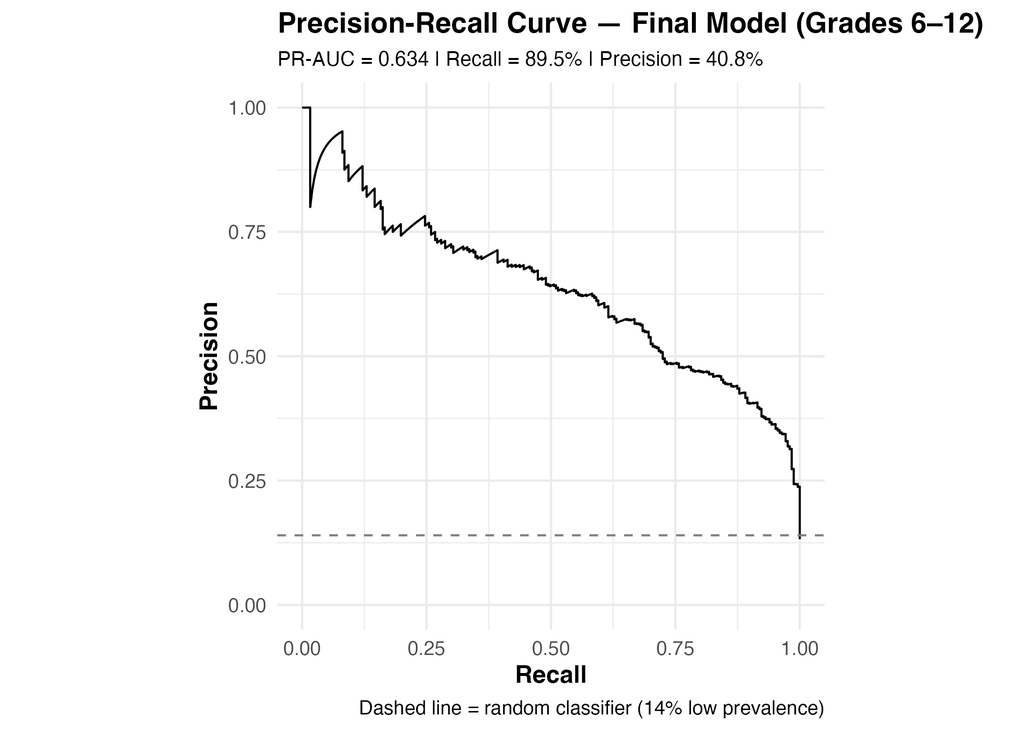

The precision–recall curve illustrates how the model balances correctly identifying low-success students (recall) against the proportion of flagged students who are truly low-success (precision). The model achieves strong recall across most thresholds, reflecting its ability to detect the majority of at-risk students, while maintaining precision well above the random-chance baseline of 14%. The resulting PR-AUC of 0.634 indicates substantially better minority-class ranking performance than would be expected by chance.

These results indicate that the model is optimized toward **high recall for the low-success group**, which aligns with the project goal of minimizing false negatives (i.e., failing to detect at-risk students). The tradeoff is a higher false-positive rate, meaning some high-success students are flagged as low. This pattern is consistent with the class weighting and the PR-AUC–driven tuning procedure, which prioritize identifying as many at-risk students as possible.

Importantly, in an educational context, the “cost” of these false positives may not be strictly negative. Students incorrectly flagged as low-success may still benefit from additional academic support, mentoring, or resource allocation. Such interventions can reinforce positive behaviors, bolster engagement, and help counteract patterns associated with multigenerational academic disadvantage. Thus, while the model errs on the side of over-identification, this may serve a broader equity-oriented purpose by expanding access to supportive structures that promote long-term success.

## Comparison of Alternative SVM Models

Moderate performance was exhibited by the **5-component model**, characterized by a test PR-AUC of 0.517 and a noticeable decline in ROC-AUC and overall accuracy. Recall for the low-success group dropped to 0.814, and the count of false negatives nearly doubled relative to the 10-component model. Despite a higher overall flagging rate, precision remained lower, suggesting weaker ability in ranking the minority class.

The weakest performance of the three was observed in the **3-component model**. With a test PR-AUC of 0.475 and the lowest ROC-AUC (0.849), significant difficulty in separating low- and high-success students was apparent. Recall fell to 0.785, while false negatives increased to 53. Although fewer false positives were produced compared to the 5-component model, the lower discriminative performance suggests a substantial loss of predictive signal upon reducing dimensionality to three components.

Overall, the comparison indicates that overly aggressive reduction of the PCAmix representation degrades minority-class detection and ranking quality. The **10-component model** was found to offer the most balanced and effective performance, preserving sufficient mixed-data structure to support high recall and strong PR-AUC while maintaining acceptable precision and accuracy.

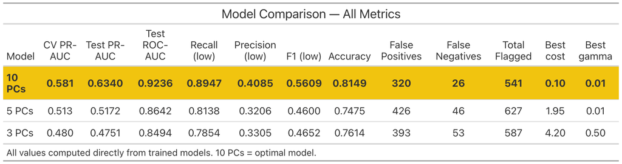

# Conclusion

This project set out to deconstruct the complex, often non-linear drivers of secondary student academic success. By coupling dimensionality reduction (PCAmix) with a Bayesian-optimized Support Vector Machine, we established a modeling framework capable of navigating the “mixed manifold” of educational data—a space defined by the friction between rigid structural categories and fluid human behaviors.

**Future Directions** While this analysis provides a robust snapshot of the 2019 educational landscape, it is limited by its cross-sectional nature. Future work would benefit from longitudinal data to determine if the “reactive” help observed here eventually transitions into independent success over time. Additionally, expanding the feature set to include school-level funding and resource data could help disentangle the effects of home environment from institutional quality.

Ultimately, this analysis demonstrates that predicting student success requires looking beyond simple metrics of “involvement.” By leveraging advanced statistical learning to detect the subtle signals within the noise, we can move toward a more nuanced understanding of how to support the whole student—shifting the focus from reactive intervention to the cultivation of resilient, independent learners.